# Project 1 Report - Sleep and Activity - Lucas Carlson

## 1. Introduction

I have gathered two datasets that separately describe my activity and my sleep over a time period of about the previous two years. My activity has been tracked daily for years thanks to my Apple Watch and was exported to a CSV file through the use of a third party app on my iPhone. I have tracked my sleep using an app on my iPhone for many years and I used that app directly to exports the data it collected on my sleep also in the form of a CSV. This data is interesting to me because it allows me to reflect on the information that I have been gathering and compare it in a way that I wasn’t able to before. A unique row of the activity dataset represents daily averages and totals of my activity, as collected by my iPhone and my Apple Watch. A unique row of the sleep dataset represents one night where I used the sleep tracking app to track my sleep, and the data it collected during that time. The easiest way to join the datasets will be by making use of the dates to match my activity with the previous nights sleep. Both datasets contain primarily numeric variables that describe one statistic, like the time I was asleep or the amount of calories I burned in a day, although there are a few categorical variables as well, such as the weather condition during the night. I expect there to be a relationship between the amount and quality of my sleep with the amount of activity I had during the following day. I would also expect to see trends individually in my activity and my sleep in how they change given the day of the week. Finally, I also expect to see relationships between my activity and sleep and the day of the week. My research question is to investigate what impact does my previous nights sleep have on my activity for that current day.

Now I’ll load the datasets from their CSV’s.

```r
sleep_data <- read_delim("sleepdata.csv", delim=";")
head(sleep_data)
```

```
## # A tibble: 6 × 21
##   Start               End                 Sleep Qu…¹ Regul…² Mood  Heart…³ Steps
##   <dttm>              <dttm>              <chr>      <chr>   <lgl>   <dbl> <dbl>
## 1 2015-10-30 23:06:22 2015-10-31 07:38:32 75%        0%      NA          0  4418
## 2 2015-10-31 23:10:18 2015-11-01 08:05:56 100%       0%      NA          0  2331
## 3 2015-11-01 21:35:41 2015-11-02 06:05:33 99%        70%     NA          0  2623
## 4 2015-11-02 22:45:50 2015-11-03 06:25:47 89%        83%     NA          0  6239
## 5 2015-11-03 23:38:45 2015-11-04 06:02:31 58%        85%     NA          0  7005
## 6 2015-11-04 23:28:50 2015-11-05 06:09:20 79%        94%     NA          0  6818
## # … with 14 more variables: `Alarm mode` <chr>, `Air Pressure (Pa)` <dbl>,
## #   City <chr>, `Movements per hour` <dbl>, `Time in bed (seconds)` <dbl>,
## #   `Time asleep (seconds)` <dbl>, `Time before sleep (seconds)` <dbl>,
## #   `Window start` <dttm>, `Window stop` <dttm>, `Did snore` <lgl>,
## #   `Snore time` <dbl>, `Weather temperature (°F)` <dbl>, `Weather type` <chr>,
## #   Notes <lgl>, and abbreviated variable names ¹`Sleep Quality`, ²Regularity,
## #   ³`Heart rate (bpm)`
```

```r
health_data <- read_csv("healthdata.csv")
head(health_data)
```

```
## # A tibble: 6 × 107
##   Date   Activ…¹ Alcoh…² Apple…³ Apple…⁴ Apple…⁵ Apple…⁶ Basal…⁷ Basal…⁸ Blood…⁹
##   <chr>    <dbl> <lgl>     <dbl> <lgl>     <dbl>   <dbl> <lgl>     <dbl> <lgl>
## 1 2/15/…    313. NA           28 NA           11     155 NA         1409 NA
## 2 2/16/…    161. NA           NA NA           12      52 NA         1408 NA
## 3 2/17/…    320. NA           16 NA           13     224 NA         1417 NA
## 4 2/18/…    265. NA            8 NA           11     127 NA         1415 NA
## 5 2/19/…    127. NA           NA NA           12      48 NA         1409 NA
## 6 2/20/…    129. NA            1 NA            9      49 NA         1405 NA
## # … with 97 more variables: `Blood Glucose (mg/dL)` <lgl>,
## #   `Blood Oxygen Saturation (%)` <lgl>,
## #   `Blood Pressure [Systolic] (mmHg)` <lgl>,
## #   `Blood Pressure [Diastolic] (mmHg)` <lgl>, `Body Fat Percentage (%)` <lgl>,
## #   `Body Mass Index (count)` <lgl>, `Body Temperature (degF)` <lgl>,
## #   `Calcium (mg)` <lgl>, `Carbohydrates (g)` <lgl>, `Chloride (mg)` <lgl>,
## #   `Chromium (mcg)` <lgl>, `Copper (mg)` <lgl>, …
```

As can seen by looking at the first couple of rows of each dataset there are a lot of columns that contain little to no information that are given to us by the data sources, I will eliminate these empty columns later in the data wrangling step to reduce the size of the dataset that I am working with using the dplyr functions from that part of the assignment.

## 2. Tidying

Luckily the data is already almost entirely tidy! The majority of the work will be getting the two datasets into a form that allows them to be merged in the next step.

```r
# Lets start by getting the health data into a form that allows it to be joined
health_data %>% # R stored the date in a chr format which cant be merged using a join function with the POSIXct format it used for the sleep dataset so I convert to a simpler date format
  mutate(Date = as.Date(Date, "%m/%d/%Y")) -> health_data
head(health_data$Date, 5)
```

```
## [1] "2021-02-15" "2021-02-16" "2021-02-17" "2021-02-18" "2021-02-19"
```

```r
# I want to investigate the impact that sleep has on my activity the next day so it makes the most sense to join the activity with the day that I woke up. To do this I convert the time and date that I woke up in a POSIXct format, called End in the dataset, into a simple Date format, with the time removed, and save that as a new column as to not lose any information.
sleep_data %>%
  mutate(Date = as.Date(End)) -> sleep_data
head(sleep_data$Date, 5)
```

```
## [1] "2015-10-31" "2015-11-01" "2015-11-02" "2015-11-03" "2015-11-04"
```

Now I can see that the Date, which is the ID variable, is in the same format for both datasets and my data is otherwise tidy so I can move on to merging.

## 3. Joining / Merging

Before I merge, lets look at some overview statistics of the datasets.

```r
# I'll start with finding the total number of observations in each dataset using a length function on a column
length(health_data$Date)
```

```
## [1] 738
```

```r
length(sleep_data$Date)
```

```
## [1] 1531
```

That’s 738 observations in the health dataset and 1,531 observations in the sleep dataset. That generally makes sense as the health dataset covers about the last two years which is around 2*365 = 730 and the sleep datasest is only the nights that I actually used the app to record my sleep since 2015 so plenty of time to accumulate fifeteen hundred observations.

```r
# Next, I'll look at the column names in each dataset to find the ID's for each dataset
colnames(health_data)
```

```
##  [1] "Date"
##  [2] "Active Energy (kcal)"
##  [3] "Alcohol Consumption (count)"
##  [4] "Apple Exercise Time (min)"
##  [5] "Apple Sleeping Wrist Temperature (degF)"
##  [6] "Apple Stand Hour (count)"
##  [7] "Apple Stand Time (min)"
##  [8] "Basal Body Temperature (degF)"
##  [9] "Basal Energy Burned (kcal)"
## [10] "Blood Alcohol Content (%)"
## [11] "Blood Glucose (mg/dL)"
## [12] "Blood Oxygen Saturation (%)"
## [13] "Blood Pressure [Systolic] (mmHg)"
## [14] "Blood Pressure [Diastolic] (mmHg)"
## [15] "Body Fat Percentage (%)"
##  [ reached getOption("max.print") -- omitted 92 entries ]
```

```r
colnames(sleep_data)
```

```
##  [1] "Start"                       "End"
##  [3] "Sleep Quality"               "Regularity"
##  [5] "Mood"                        "Heart rate (bpm)"
##  [7] "Steps"                       "Alarm mode"
##  [9] "Air Pressure (Pa)"           "City"
## [11] "Movements per hour"          "Time in bed (seconds)"
## [13] "Time asleep (seconds)"       "Time before sleep (seconds)"
## [15] "Window start"
##  [ reached getOption("max.print") -- omitted 7 entries ]
```

That’s a lot of columns! Luckily closer examination shows that there is very little overlap of ID variables between the two datasets which makes sense because one dataset is about when I am asleep and the other is about when I am awake. The main ID variable, and the shared ID variable, is the Date variable in both datasets which describes the date that the health data was collected on or the date when I woke up. By inspection of the other columns in the health dataset I can see that it has no more ID variables because each subsequent column includes information about a specific part of that day like the amount of active energy I burnt that day, etc. These variables would not make good ID variables because they are not specific to a row or unique among rows leaving Date as the only ID variable for the health data. I do want to mention again that many of these columns are empty as I do not, for example, track my vitamin intake among other things and these empty rows will be removed in the data wrangling section when I have access to the select function. As for the sleep dataset it has some ID variables that do not overlap with the health dataset. These variables are the Start and End times of each time I slept, the end time I converted to be the ID variable Date as described above so it’s kind of already being used and the start time I chose not to use as the ID variable because I wanted to investigate the relationship that my sleep had on my next day activity as I described above. All of the other columns would not make good ID variables as they just describe that sleep session in some non-unique way, like describing how long I was asleep in seconds which could be repeated over the course of a few years. When joining, I only care about the days where I have both sleep data and activity data I can do a simple inner join to select only the rows from each dataset where the same date ID variable exists.

```r
combined_data <- inner_join(sleep_data, health_data, by="Date")
# I can now use the same length on the date column as earlier to find the new number of observations in the joined dataset
length(combined_data$Date)
```

```
## [1] 344
```

So the new combined length is 344 observations or 344 days where I both tracked my sleep the night before and tracked my activity with my apple watch. Because there were 738 + 1531 = 2269 observations before that means that 2269 - 344 = 1925 observations or days were dropped where I either didn’t track my sleep, I didn’t wear my apple watch to track my activity, or the time range of the datasets otherwise prevented an observation from combining. Because I used an inner join I did not lose any columns or ID variables after merging. One potential issue with this dataset is that I am relying on having sleep data from days that I actively tracked it which are also days that I had a wake-up time, this means that any lazy days on my part where I slept in are not included in this data. Other than that issue and any other issue that stems from the reliability of the original data, there were no issues in the merging process so I can continue into data wrangling.

## 4. Wrangling

The first thing to do is to drop all of these dead columns using a select function.

```r
length(combined_data)
```

```
## [1] 128
```

Before I begin there are 128 columns of which I’m not sure how many contain data, lets see how many remain after removing the empty columns.

```r
# Using select I can select only the columns that contain information. To find these non-empty columns I use a which function to select only the columns that contain a non NA element for the first two observations because only rows that are completely empty (all NAs) begin with multiple NA columns while some rows that are partially filled might have an NA element as part of the first two rows.
combined_data %>%
  select( # Select to keep only the columns described by the which function
    which( # Which lists the columns that follow the following expression
      !is.na(combined_data[1,]) | # The columns must have a non-NA value in the first or second row
      !is.na(combined_data[2,]))
  ) -> combined_data # Save back to combined data to make future handling of the data easier
head(combined_data) # Look at an overview of the reduced dataset for discussion below
```

```
## # A tibble: 6 × 42
##   Start               End                 Sleep …¹ Regul…² Heart…³ Steps Alarm…⁴
##   <dttm>              <dttm>              <chr>    <chr>     <dbl> <dbl> <chr>
## 1 2021-02-15 00:55:58 2021-02-15 08:46:43 84%      90%           0  1654 Normal
## 2 2021-02-16 00:46:52 2021-02-16 08:59:04 99%      97%           0  8836 Normal
## 3 2021-02-24 00:03:43 2021-02-24 08:55:10 100%     0%            0  2216 Normal
## 4 2021-02-25 00:44:39 2021-02-25 08:50:33 90%      94%           0  7145 Normal
## 5 2021-02-26 00:52:41 2021-02-26 08:59:00 93%      96%           0  2071 Normal
## 6 2021-02-28 01:20:12 2021-02-28 09:48:55 96%      93%           0  3469 Normal
## # … with 35 more variables: `Air Pressure (Pa)` <dbl>, City <chr>,
## #   `Movements per hour` <dbl>, `Time in bed (seconds)` <dbl>,
## #   `Time asleep (seconds)` <dbl>, `Time before sleep (seconds)` <dbl>,
## #   `Window start` <dttm>, `Window stop` <dttm>, `Did snore` <lgl>,
## #   `Snore time` <dbl>, `Weather temperature (°F)` <dbl>, `Weather type` <chr>,
## #   Date <date>, `Active Energy (kcal)` <dbl>,
## #   `Apple Exercise Time (min)` <dbl>, `Apple Stand Hour (count)` <dbl>, …
```

```r
length(combined_data)
```

```
## [1] 42
```

By checking the head I can see that selecting the columns in this way did not affect the actual data in the dataset and the length shows that there are now only 42 columns to work with that have data in them which is much nicer to deal with than the 128 columns before I removed the empty ones. Next I’m going to use mutate to create a new variable that is a function of at least another variable. My sleep data gave me a percentage called sleep quality, I don’t know how that percentage was determined but I think that it could be interesting to have an effective sleep quality which is this sleep quality number times the length of time that I was asleep that night.

```r
combined_data %>% # From the combined dataset
  mutate(`Effective Sleep Quality` = # Save the new variable into Effective Sleep Quality
           as.numeric(sub("%", "", `Sleep Quality`))/100 * # convert the sleep quality from a chr to a number dividing by 100 to get the percentage
           `Time asleep (seconds)` # multiply by the seconds asleep
  ) -> combined_data # save as a new row back into the combined dataset
head(combined_data$`Effective Sleep Quality`)
```

```
## [1] 21669.98 28359.04 28272.70 22740.03 22432.90 25493.18
```

A quick check of the first few elements of the new column and everything looks to be in order, next I’ll calculate some summary statistics for my time asleep, my activity, and the weather while I slept. This includes two numeric variables and one categorical variable.

```r
# I'll start by using the simple summary function to find some key values, like the mean min and max, of both the Time asleep in seconds and the Active Energy in kcal by using a select function to specify only those two columns.
combined_data %>% select("Time asleep (seconds)", "Active Energy (kcal)") %>% summary()
```

```
##  Time asleep (seconds) Active Energy (kcal)
##  Min.   : 3175         Min.   :  0.003
##  1st Qu.:19932         1st Qu.:185.820
##  Median :23109         Median :270.890
##  Mean   :22808         Mean   :284.429
##  3rd Qu.:25497         3rd Qu.:366.035
##  Max.   :34188         Max.   :765.900
##                        NA's   :21
```

```r
# Next, I find some summary stats of the weather type as recorded at each night when I began sleeping
combined_data %>%
  group_by(`Weather type`) %>% # Make groups based on the weather type
  summarize(count = n(), # find the number of each weather type
            percentage = n()/length(combined_data$Date)*100) # find the percentage of each weather type
```

```
## # A tibble: 9 × 3
##   `Weather type` count percentage
##   <chr>          <int>      <dbl>
## 1 Cloudy            74     21.5
## 2 Fair              22      6.40
## 3 Fog                5      1.45
## 4 No weather        15      4.36
## 5 Partly cloudy     59     17.2
## 6 Rain              28      8.14
## 7 Rainy showers      4      1.16
## 8 Snow               2      0.581
## 9 Sunny            135     39.2
```

First, the mean time that I sleep is 22808 seconds which is about 6.5 hrs. That seems a little low to me but there are a few things to keep in mind. First this is the time asleep not my time in bed, so if it took me 30 mins to fall asleep every night then I would be in bed for 7 hrs which seems more reasonable. Second, by the very nature of this only nights where I set an alarm were tracked so any nights where I slept in without an alarm, presumably for longer than 6.5 hrs, are not included in the dataset, bringing the average down. As for active energy, which is energy burned only from being active excluding resting energy burn, I averaged 284 kcal. My max over that time period was a little less than three times as much at 765 kcal. Interestingly there were 21 days that had an NA active energy but despite, on closer inspection, having other health information. My only guess for these days is that there was some problem with how the Apple Watch collects data that caused errors on a small subset of the days over the two year time period that are manifesting here as NAs and so they should probably be removed in further investigation of Active Energy. As for the categorical variable of weather type I found that most days, about 39% of days, the weather was sunny while cloudy and partly cloudy made up the next most common weather types. Next I’m going to create a summary statistic so that I use the reaming dplyr functions and the pivot_longer function from earlier. This final summary statistic is a little odd so that I could use all of the functions that I need to. The statistic looks at what if I had instead chosen to correlate my activity with the following nights sleep instead of the previous nights sleep with my activity. I then also summarize each day into its weekday to help give a overview when looking at the data once the average is finalized. So, the final statistic shows whether the row is based on the start or end of the sleep recording indicating that it is respectively correlated to the following or previous night, then what weekday it is and finally the average of the active energy burnt for that weekday, arranged in descending order of that energy.

```r
# Calculate the statistic from the combined data as described above
combined_data %>%
  filter(!is.na(`Active Energy (kcal)`)) %>% # Remove all rows with NA active energy as described above
  mutate(Start = weekdays(Start), End = weekdays(End)) %>% # Convert the start and end times to their weekday equivalent from their date format
  pivot_longer(c(`Start`, `End`), values_to = "Weekday", names_to = "Sleep Type") %>% # pivot out start and end so that they are each on their own row under the new column weekday with the type (start or end) being under its own column sleep type
  group_by(`Sleep Type`, `Weekday`) %>% # group by sleep type and then also by weekday
  summarize(`Average Active Energy (kcal)` = mean(`Active Energy (kcal)`)) %>% # find the average active energy in those groups
  arrange(desc(`Average Active Energy (kcal)`)) # arrange so that the highest active energy is presented at the top of the list
```

```
## # A tibble: 14 × 3
## # Groups:   Sleep Type [2]
##    `Sleep Type` Weekday   `Average Active Energy (kcal)`
##    <chr>        <chr>                              <dbl>
##  1 End          Wednesday                           328.
##  2 End          Monday                              323.
##  3 Start        Wednesday                           317.
##  4 Start        Monday                              316.
##  5 End          Saturday                            310.
##  6 Start        Friday                              301.
##  7 Start        Saturday                            293.
##  8 End          Friday                              268.
##  9 End          Thursday                            267.
## 10 Start        Thursday                            260.
## 11 Start        Tuesday                             255.
## 12 End          Tuesday                             241.
## 13 End          Sunday                              236
## 14 Start        Sunday                              228.
```

What this statistic shows is that when my sleep ended on a Wednesday is when I burned the most calories and Monday the second most, this corresponds when my sleep started on a Wednesday I also burned a larger than average number of calories. Many of the values are similar for both when I started and stopped on a given weekday because I have a tendency to fall asleep after midnight which places those two observations on the same weekday.

## 5. Visualizing

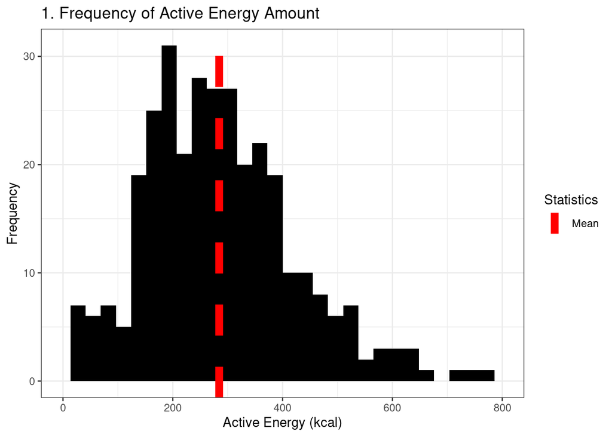

```r
combined_data %>%
  filter(!is.na(`Active Energy (kcal)`)) %>% # Remove all rows with NA active energy
  ggplot(aes(x = `Active Energy (kcal)`)) + # Create a histogram plot based on the active energy
    geom_histogram(fill="Black") +
    geom_vline(aes(xintercept = mean(`Active Energy (kcal)`), color="Mean"), size = 3, linetype="dashed") + # add a line at the mean
    scale_color_manual(name = "Statistics", values = c(Mean = "red")) + # color the line red and change the legend to say statistics to better describe it
    theme_bw() + # chagnge the theme
    scale_x_continuous(limits = c(0, 800), breaks = seq(0, 800, 200)) + # change the scale
    labs(y = "Frequency", x = "Active Energy (kcal)", title = "1. Frequency of Active Energy Amount") # add labels
```

This plot depicts the distribution of my Active Energy, which is the energy that I burned above my resting energy in kcal. It also uses a stat function, the mean, to add a vertical line showing where the mean of the graph is. I can see that relationship in the graph is that it is fairly normally distributed.

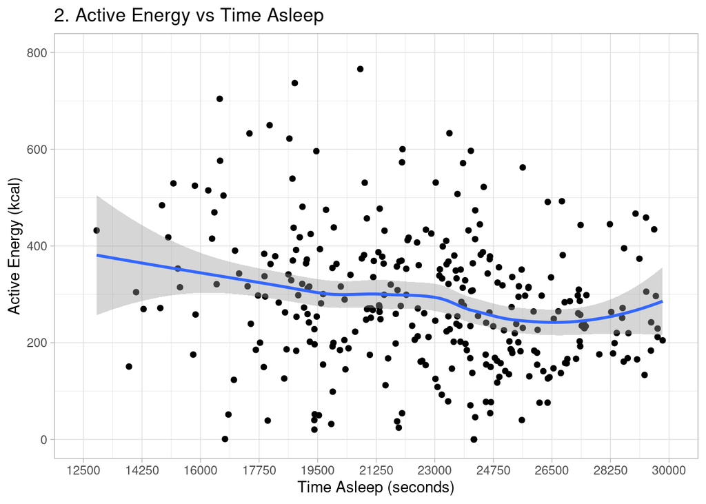

```r
combined_data %>%
  filter(!is.na(`Active Energy (kcal)`)) %>% # Remove all rows with NA active energy
  ggplot(aes(x = `Time asleep (seconds)`, y = `Active Energy (kcal)`)) + # create a plot of active energy vs time asleep where each point represents one observation from the dataset
    geom_point() + # make it a point plot
    geom_smooth() + # add a smoothed regression line
    theme_light() + # change the theme
    scale_x_continuous(limits = c(12500, 30000), breaks = seq(12500, 30000, 1750)) + # change the x scale
    scale_y_continuous(limits = c(0, 800), breaks = seq(0, 800, 200)) + # change the y scale
    labs(x = "Time Asleep (seconds)", y = "Active Energy (kcal)", title = "2. Active Energy vs Time Asleep") # add labels
```

This graph depicts the Active Energy in kcal vs the Time Asleep in seconds. From this graph I can see that there is little to no sustained relationship between the two variables from the trend line. I had expected there to be a relationship between these variables but the data shown in this graph does not show a significant relationship.

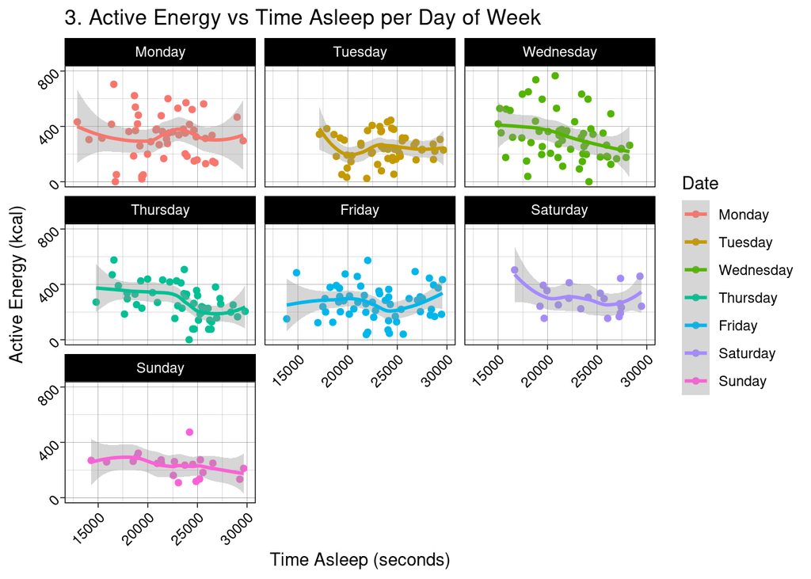

```r
combined_data %>%
  filter(!is.na(`Active Energy (kcal)`)) %>% # Remove all rows with NA active energy
  mutate(Date = factor(weekdays(Date), levels=c("Monday", "Tuesday", "Wednesday", "Thursday", "Friday", "Saturday", "Sunday"))) %>% # change the date to the day of week and provide ordered levels so the days appear in the graph in week order
  ggplot(aes(x = `Time asleep (seconds)`, y = `Active Energy (kcal)`, color=`Date`)) + # create the same plot as before but now separated by week
    geom_point() + # add the points
    geom_smooth() + # add regression lines
    facet_wrap(~Date) + # seperate by day of week
    theme_linedraw() + # change the theme
    scale_x_continuous(limits = c(12500, 30000), breaks = seq(15000, 30000, 5000)) + # change the x scale
    scale_y_continuous(limits = c(0, 800), breaks = seq(0, 800, 400)) + # change the y scale
    theme(axis.text = element_text(angle = 45, hjust = 1)) + # tilt the axis text for greater readability
    labs(x = "Time Asleep (seconds)", y = "Active Energy (kcal)", title = "3. Active Energy vs Time Asleep per Day of Week") # add labels
```

The final graph also depicts the active energy in kcal vs the time asleep in seconds but this graph separates out each day of the week into its own plot. Again this graph shows that there is no, or almost no, relationship between the active energy and the time asleep and that relationship, or lack there of, does not change depending on the day of the week.

## 6. Discussion

As for the process of conducting this project I found it to be rewarding when I was creating the final graphs but also disappointing because of their lack of correlation. I found it to be challenging to incorporate a pivot function given the nature of my data and challenging to complete such a large project by myself. I also found it challenging to incorporate the R code and data into something resembling a research paper, hopefully I did it well. I have learned a lot about what goes into working with large datasets and how to present a result that I was not expecting.